# Changes in R/qtl2 version 0.5

The internal data structures for [R/qtl2](http://kbroman.org/qtl2) version 0.5 have undergone major changes. In addition, in several places, QTL analysis now requires additional steps and the need to keep track of additional objects.

The main differences are that the genotype probabilities from `qtl2geno::calc_genoprob` and the genome scan results from `qtl2scan::scan1` (as well as estimated QTL effects from `qtl2scan::scan1coef` and `qtl2scan::scan1blup`) no longer include the genetic map of marker/pseudomarker locations.

To convert data structures from the old format to the new format, we provide functions `convert_probs()` and `convert_scan1()` in the file `convert_04_to_05.R`.

## Genotype probabilities

First, the genotype probabilities produced by `qtl2geno::calc_genoprob` no longer include the genetic map of marker/pseudomarker positions, and calculating these probabilities generally requires one extra step.

Let’s load some sample data.

```r
library(qtl2geno)
iron <- read_cross2(system.file("extdata", "iron.zip", package="qtl2geno"))
```

The `calc_genoprob` function no longer takes arguments `step`, `stepwidth`, and `off_end`. Instead, you need to first call `insert_pseudomarkers()` to insert pseudomarker positions.

```r
map <- insert_pseudomarkers(iron$gmap, step=1)
```

You then call `calc_genoprob` using that map, with the pseudomarker positions inserted. Alternatively, you could use `iron$gmap` directly, and do the calculations solely at the markers.

```r
pr <- calc_genoprob(iron, map, error_prob=0.002, map_function="c-f")
```

## Genome scan

A genome scan with `qtl2scan::scan1` is performed as before, but the result no longer includes the genetic map of marker/pseudomarker positions, and so later use of these results generally require that you provide **both** the results and the map.

We first get the special covariates for the X chromosome.

```r
Xcovar <- get_x_covar(iron)
```

Then we perform the genome scan.

```r
library(qtl2scan)
out <- scan1(pr, iron$pheno, Xcovar=Xcovar)
```

We can use `qtl2scan::find_peaks` to get a summary of inferred QTL meeting some LOD threshold, but this function needs both the `scan1` output and the map of marker/pseudomarker positions.

```r
find_peaks(out, map, threshold=4)
```

```
##   lodindex lodcolumn chr  pos       lod
## 1        1     liver   2 56.8  4.956559
## 2        1     liver   7 50.1  4.050449
## 3        1     liver  16 28.6  7.682563
## 4        2    spleen   8 13.6  4.302929
## 5        2    spleen   9 56.6 12.062549
```

Similarly, to plot the results, we need to provide both the `scan1` output and the map.

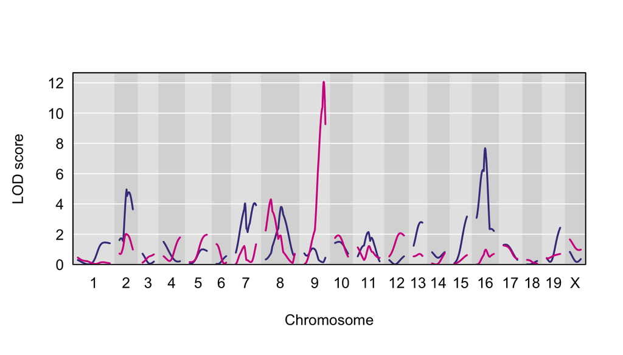

```r
library(qtl2plot)
plot(out, map, ylim=c(0, maxlod(out)*1.05))
plot(out, map, lodcolumn=2, col="violetred", add=TRUE)
```

Moreover, to subset `scan1` results, you need to provide both the `scan1` object and the map.

```r
out_selectedchr <- subset(out, map, chr=c(2, 7, 8, 9, 16))
```

Previously, when subsetting `scan1` objects with brackets (`[ ]`), it was done with `scan1_output[chr, lodcolumns]`, but we have dropped this feature for now. To subset by chromosome, you need to explicitly use `subset()`, while the bracket notation just subsets the object as a matrix `scan1_output[positions, lodcolumns]`.

## SNP association analyses

In analysis of SNP association, with a table of SNP information and the function `qtl2scan::genoprob_to_snpprob()`, there’s now an additional step, and the SNP information table is no longer included in the results, but needs to be provided separately.

Let’s first load the `DOex` example, which is a subset of the data from subset of the data from [Recla et al. (2014)](http://www.ncbi.nlm.nih.gov/pubmed/24700285).

```r
file <- paste0("https://raw.githubusercontent.com/rqtl/",
               "qtl2data/master/DOex/DOex.zip")
DOex <- read_cross2(file)
```

Let’s first do a single-QTL genome scan with the haplotype dosages.

```r
pr <- calc_genoprob(DOex, error_prob=0.002)
apr <- genoprob_to_alleleprob(pr)
k <- calc_kinship(apr, "loco")
sex <- (DOex$covar$Sex == "male")*1
names(sex) <- rownames(DOex$covar)
out <- scan1(apr, DOex$pheno, k, sex)
```

Consider the peak marker on chromosome 2. We find it’s physical location:

```r
marker <- rownames(max(out, DOex$gmap, chr="2"))
peak_Mbp <- DOex$pmap[["2"]][marker]
```

We now grab SNP information for the region.

```r
tmpfile <- tempfile()
file <- "https://raw.githubusercontent.com/rqtl/qtl2data/master/DOex/c2_snpinfo.rds"
download.file(file, tmpfile, quiet=TRUE)
snpinfo <- readRDS(tmpfile)
unlink(tmpfile)
```

We convert the founder genotypes to a “strain distribution pattern” (SDP): an integer whose binary encoding corresponds to the 8 founders’ genotypes.

```r
snpinfo$sdp <- calc_sdp(snpinfo[,-(1:4)])
```

Previously, `qtl2scan::genoprob_to_snpprob` would first partition the SNPs into groups of equivalent SNPs (within the same marker interval and having the same strain distribution pattern) and then collapse the genotype or haplotype probabilities to SNP genotype or allele probabilities.

The partitioning/indexing of SNPs is now a separate step:

```r
snpinfo <- index_snps(DOex$pmap, snpinfo)
```

This adds a few columns, indicating which SNPs are the non-equivalent ones, and which marker intervals they belong to.

We then can call `qtl2scan::genoprob_to_snpprob()`, giving both the probabilities and the augmented SNP info table.

```r
snp_apr <- genoprob_to_snpprob(apr, snpinfo)
```

We can then perform a genome scan.

```r
out_snps <- scan1(snp_apr, DOex$pheno, k[["2"]], sex)
```

The function `qtl2plot::plot_snpasso()` can be used to plot the results. You need to provide both the `scan1` output and the SNP information table (augmented by `index_snps`, with the indexing information).

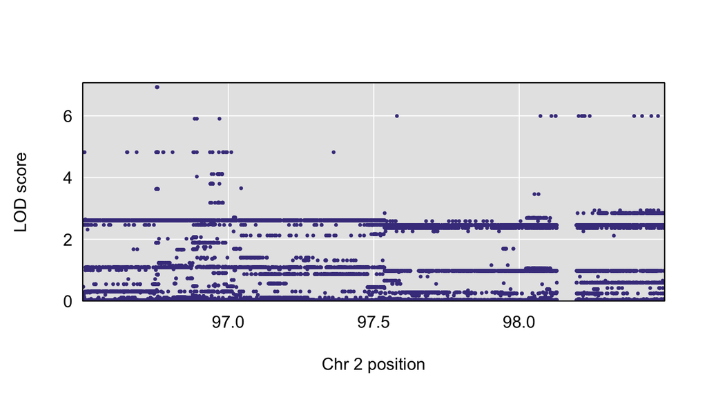

```r
plot_snpasso(out_snps, snpinfo)
```

To get a table of the SNPs with the largest LOD scores, again use the function `top_snps()`, but now you need to provide the SNP information table.

```r
top_snps(out_snps, snpinfo)
```

```
##            snp_id chr  pos_Mbp alleles AJ B6 129 NOD NZO CAST PWK WSB sdp index interval on_map      lod
## 3264  rs212414861   2 96.75489     C|G  1  1   1   1   3    3   1   1  48  3264       64  FALSE 6.931185
## 3265  rs229578122   2 96.75494     T|A  1  1   1   1   3    3   1   1  48  3264       64  FALSE 6.931185
## 3266  rs254318131   2 96.75494     C|T  1  1   1   1   3    3   1   1  48  3264       64  FALSE 6.931185
## 3267  rs217679969   2 96.75495     G|T  1  1   1   1   3    3   1   1  48  3264       64  FALSE 6.931185
## 3268  rs238404461   2 96.75496     T|G  1  1   1   1   3    3   1   1  48  3264       64  FALSE 6.931185
## 3269  rs262749925   2 96.75497     C|G  1  1   1   1   3    3   1   1  48  3264       64  FALSE 6.931185
## 3271  rs231282689   2 96.75498   C|G/T  1  1   1   1   3    3   1   1  48  3264       64  FALSE 6.931185
## 3274  rs260286709   2 96.75518     G|A  1  1   1   1   3    3   1   1  48  3264       64  FALSE 6.931185
## 3275   rs27396282   2 96.75522     T|C  1  1   1   1   3    3   1   1  48  3264       64  FALSE 6.931185
## 3283  rs263841533   2 96.75541     T|C  1  1   1   1   3    3   1   1  48  3264       64  FALSE 6.931185
## 3288  rs231205920   2 96.75557     G|A  1  1   1   1   3    3   1   1  48  3264       64  FALSE 6.931185
## 3289  rs242885221   2 96.75656     T|C  1  1   1   1   3    3   1   1  48  3264       64  FALSE 6.931185
## 5242  rs586746690   2 96.88443     C|T  1  1   3   1   3    3   1   1  52  5242       64  FALSE 5.904999
## 5426   rs49002164   2 96.89204     G|A  1  1   3   1   3    3   1   1  52  5242       64  FALSE 5.904999
```

[output cut: 16 more lines]

[Karl Broman](http://kbroman.org)